# Does Scandal Coverage Change What Trump Talks About?

## The research question, plotted

To answer the research question we plot three lines on one timeline: NYT damaging coverage, Trump conflict language, Trump environmental language. Shaded bands are the high-damage weeks from the quartile cut above.

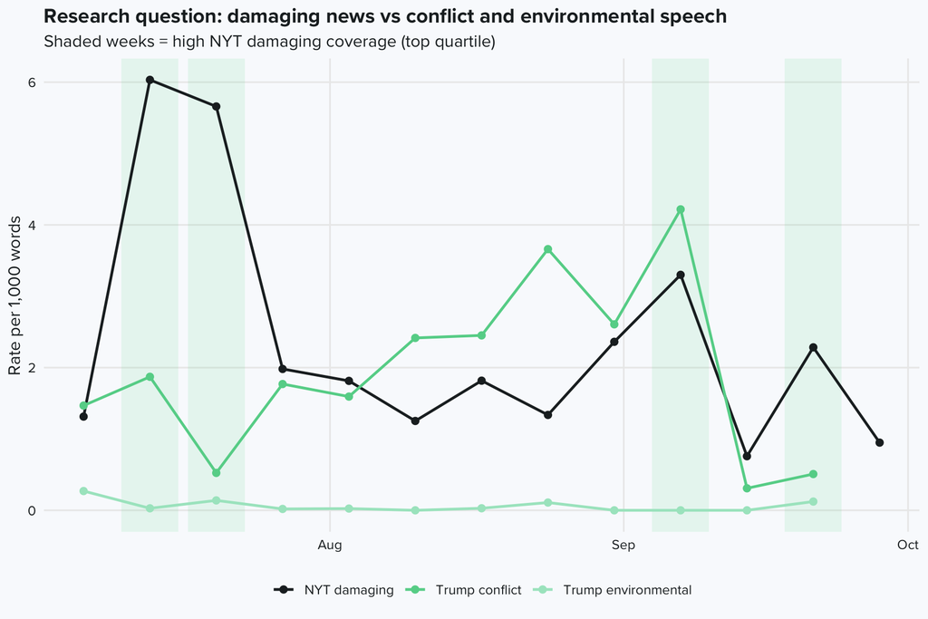

```r
# Align NYT damaging rate with Trump conflict + environmental on one timeline
rq <- weekly_rates |>
  filter(source == "NYT") |>
  select(week, nyt_damage = damage) |>
  full_join(
    weekly_rates |>
      filter(source == "Trump") |>
      select(week, speech_conflict = conflict, speech_env = env),
    by = "week"
  ) |>
  mutate(high_damage = week %in% high_weeks)

rq_long <- rq |>
  pivot_longer(
    c(nyt_damage, speech_conflict, speech_env),
    names_to = "series",
    values_to = "rate"
  ) |>
  mutate(
    series = recode(
      series,
      nyt_damage = "NYT damaging",
      speech_conflict = "Trump conflict",
      speech_env = "Trump environmental"
    )
  )

ggplot(rq_long, aes(week, rate, color = series)) +
  # Shade weeks where NYT damaging coverage is in top quartile
  geom_rect(
    data = rq |> filter(high_damage),
    aes(xmin = week - 3, xmax = week + 3, ymin = -Inf, ymax = Inf),
    inherit.aes = FALSE,
    fill = col_accent, alpha = 0.12
  ) +
  geom_line(linewidth = 0.9) +
  geom_point(size = 2) +
  scale_color_manual(
    values = c(
      "NYT damaging" = col_dark,
      "Trump conflict" = col_accent,
      "Trump environmental" = "#a8e6c8"
    )
  ) +
  labs(
    title = "Research question: damaging news vs conflict and environmental speech",
    subtitle = "Shaded weeks = high NYT damaging coverage (top quartile)",
    x = NULL, y = "Rate per 1,000 words", color = NULL
  ) +
  theme_project()
```

On raw rates, the three lines sit at different levels and the damaging-NYT series has sharper jumps than Trump’s conflict or environmental tracks. Z-scoring in the next figure makes co-movement easier to spot.

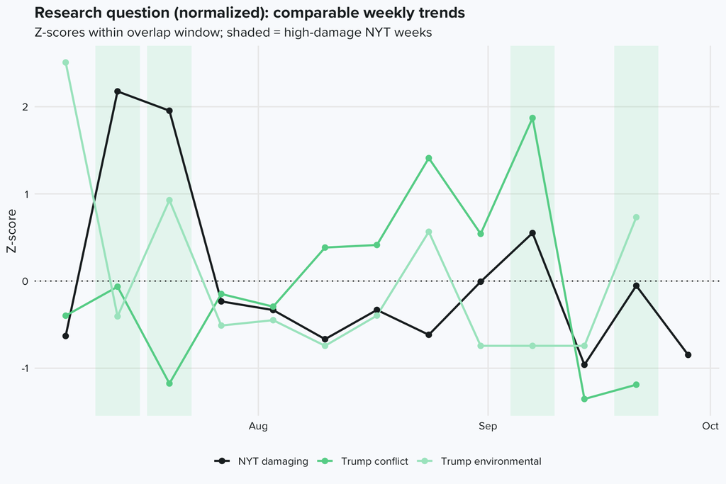

```r
# Z-score all three series within the overlap window
rq_norm <- rq |>
  mutate(
    across(c(nyt_damage, speech_conflict, speech_env), ~ {
      (.x - mean(.x, na.rm = TRUE)) / sd(.x, na.rm = TRUE)
    })
  )

rq_norm_long <- rq_norm |>
  pivot_longer(
    c(nyt_damage, speech_conflict, speech_env),
    names_to = "series",
    values_to = "z"
  ) |>
  mutate(
    series = recode(
      series,
      nyt_damage = "NYT damaging",
      speech_conflict = "Trump conflict",
      speech_env = "Trump environmental"
    )
  )

ggplot(rq_norm_long, aes(week, z, color = series)) +
  geom_rect(
    data = rq_norm |> filter(high_damage),
    aes(xmin = week - 3, xmax = week + 3, ymin = -Inf, ymax = Inf),
    inherit.aes = FALSE,
    fill = col_accent, alpha = 0.12
  ) +
  geom_hline(yintercept = 0, linetype = "dotted", color = col_dark) +
  geom_line(linewidth = 0.9) +
  geom_point(size = 2) +
  scale_color_manual(
    values = c(
      "NYT damaging" = col_dark,
      "Trump conflict" = col_accent,
      "Trump environmental" = "#a8e6c8"
    )
  ) +
  labs(
    title = "Research question (normalized): comparable weekly trends",
    subtitle = "Z-scores within overlap window; shaded = high-damage NYT weeks",
    x = NULL, y = "Z-score", color = NULL
  ) +
  theme_project()
```

On the normalized chart, conflict and damaging lines rise together in a few shaded weeks; environmental language doesn’t drop as sharply as I’d expect if the distraction story were neat and simple. Some high-damage weeks show conflict spikes with barely any movement on the environmental line.

That’s not a knockout against the idea — maybe the keyword lists miss how he talks about climate, or scandal weeks don’t automatically crowd out other topics. It’s just not the tidy “scandal up, climate down” pattern I hoped to see.

```r
rq |>
  mutate(high_damage = if_else(high_damage, "yes", "no")) |>
  arrange(week) |>
  knitr::kable(
    digits = 2,
    caption = "Weekly rates used in the research-question figure"
  )
```

Weekly rates used in the research-question figure

| week | nyt_damage | speech_conflict | speech_env | high_damage |
| --- | --- | --- | --- | --- |
| 2025-07-06 | 1.31 | 1.47 | 0.27 | no |
| 2025-07-13 | 6.03 | 1.87 | 0.03 | yes |
| 2025-07-20 | 5.66 | 0.52 | 0.14 | yes |
| 2025-07-27 | 1.98 | 1.77 | 0.02 | no |
| 2025-08-03 | 1.81 | 1.59 | 0.02 | no |
| 2025-08-10 | 1.25 | 2.42 | 0.00 | no |
| 2025-08-17 | 1.82 | 2.45 | 0.03 | no |
| 2025-08-24 | 1.34 | 3.66 | 0.11 | no |
| 2025-08-31 | 2.36 | 2.61 | 0.00 | no |
| 2025-09-07 | 3.30 | 4.22 | 0.00 | yes |
| 2025-09-14 | 0.76 | 0.31 | 0.00 | no |
| 2025-09-21 | 2.28 | 0.51 | 0.12 | yes |
| 2025-09-28 | 0.95 | NA | NA | no |

## Bing sentiment

Keyword dictionaries catch specific themes; they miss overall tone. Lab 3’s Bing lexicon is cruder — just a count of positive words minus negative words per document — but it gives a different angle on the same weeks.

One thing worth knowing: Bing scores aren’t on a −5 to +5 scale. They’re raw word counts, so long Trump speeches produce bigger numbers than short NYT snippets. That’s why the weekly z-score plot matters for comparison.

```r
bing <- get_sentiments("bing")

# Lab 3: count positive vs negative Bing words per document
bing_score_df <- function(df, text_col) {
  df |>
    filter(!is.na(date), nzchar(.data[[text_col]])) |>
    select(doc_id, date, year_month, week, text = all_of(text_col)) |>
    mutate(text = str_remove_all(text, "[^A-Za-z\\s]")) |>
    unnest_tokens(word, text) |>
    filter(str_detect(word, "^[a-z]+$"), nchar(word) > 2) |>
    anti_join(tibble(word = all_sw), by = "word") |>
    inner_join(bing, by = "word") |>
    count(doc_id, sentiment) |>
    pivot_wider(names_from = sentiment, values_from = n, values_fill = 0) |>
    mutate(bing_score = positive - negative) |>  # net word count, not a -5..5 scale
    left_join(df |> select(doc_id, date, year_month, week), by = "doc_id")
}

speech_bing <- bing_score_df(speech_df, "body_trump") |>
  mutate(source = "Trump")
nyt_bing <- bing_score_df(nyt_df, "text") |>
  mutate(source = "NYT")

bing_weekly <- bind_rows(speech_bing, nyt_bing) |>
  filter(date >= overlap_start, date <= overlap_end) |>
  group_by(week, source) |>
  summarise(mean_bing = mean(bing_score), n = n(), .groups = "drop")

bing_weekly_norm <- bing_weekly |>
  group_by(source) |>
  mutate(
    z_bing = (mean_bing - mean(mean_bing, na.rm = TRUE)) /
      sd(mean_bing, na.rm = TRUE)
  ) |>
  ungroup()
```

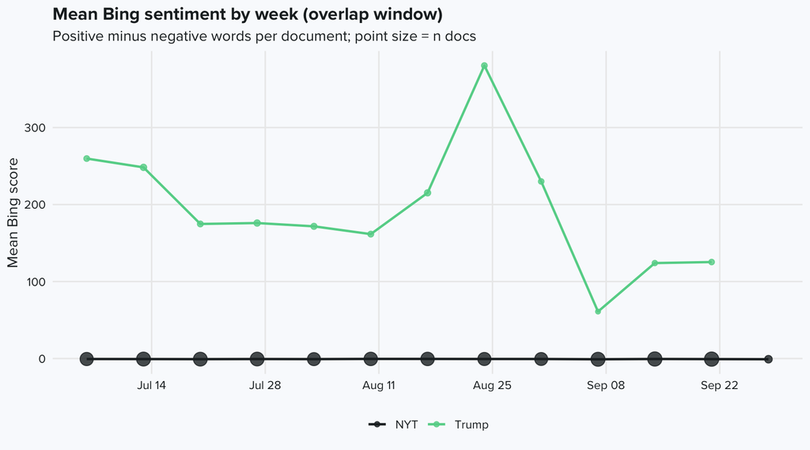

```r
bing_weekly |>
  ggplot(aes(week, mean_bing, color = source)) +
  geom_line(linewidth = 0.9) +
  geom_point(aes(size = n), alpha = 0.8) +
  scale_color_manual(values = cols_source) +
  scale_size(range = c(1.5, 5), guide = "none") +
  scale_x_date(date_labels = "%b %d", date_breaks = "2 weeks") +
  labs(
    title = "Mean Bing sentiment by week (overlap window)",
    subtitle = "Positive minus negative words per document; point size = n docs",
    x = NULL, y = "Mean Bing score", color = NULL
  ) +
  theme_project()
```

The raw weekly chart mostly shows that Trump speeches accumulate more Bing hits than NYT snippets, which is why we normalize the scores for comparison. The normalized plot below shows that the two sources often move in the same direction, especially in August, a month with flooding, interest-rate talk, and National Guard deployment in D.C. that shows up in both corpora.

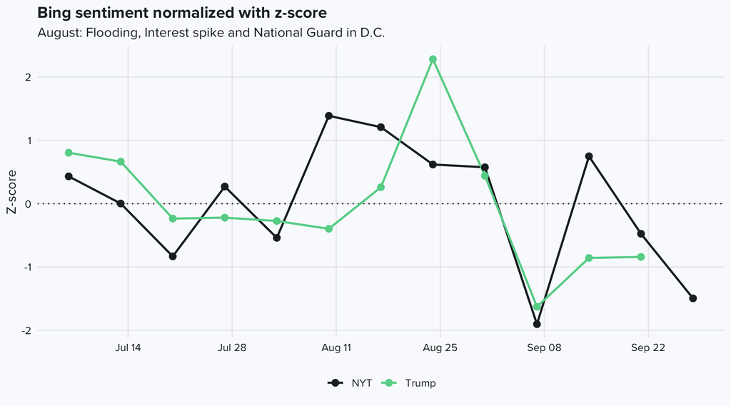

```r
bing_weekly_norm |>
  ggplot(aes(week, z_bing, color = source)) +
  geom_hline(yintercept = 0, linetype = "dotted", color = col_dark) +
  geom_line(linewidth = 0.9) +
  geom_point(size = 2.5) +
  scale_color_manual(values = cols_source) +
  scale_x_date(date_labels = "%b %d", date_breaks = "2 weeks") +
  labs(
    title = "Bing sentiment normalized with z-score",
    subtitle = "August: Flooding, Interest spike and National Guard in D.C.",
    x = NULL, y = "Z-score", color = NULL
  ) +
  theme_project()
```

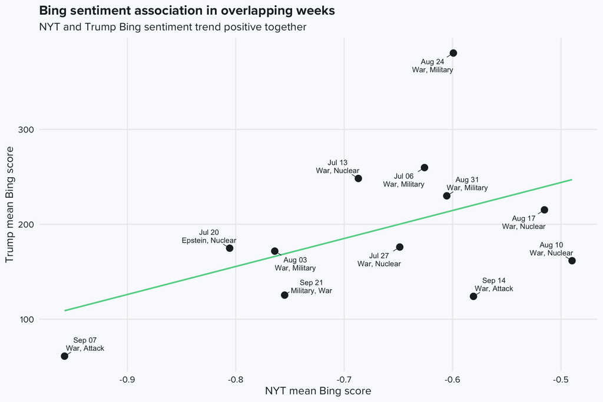

```r
# One row per week: NYT score vs Trump score for scatter + correlation
bing_wide <- bing_weekly |>
  select(week, source, mean_bing) |>
  pivot_wider(names_from = source, values_from = mean_bing)

bing_corr <- cor(bing_wide$NYT, bing_wide$Trump, use = "complete.obs")

week_tokens <- function(text_vec) {
  tibble(text = text_vec) |>
    unnest_tokens(word, text) |>
    filter(str_detect(word, "^[a-z]{3,}$")) |>
    anti_join(tibble(word = all_sw), by = "word") |>
    count(word, sort = TRUE)
}

week_shared_label <- function(wk) {
  # Top words appearing in both NYT and Trump text that week (for point labels)
  nyt_toks <- week_tokens(nyt_overlap |> filter(week == wk) |> pull(text))
  trump_toks <- week_tokens(speech_overlap |> filter(week == wk) |> pull(body_trump))
  shared <- inner_join(nyt_toks, trump_toks, by = "word", suffix = c("_nyt", "_trump")) |>
    mutate(score = n_nyt + n_trump)

  theme_words <- c(conflict_words, damage_words, env_words)
  theme_hit <- shared |> filter(word %in% theme_words) |> slice_max(score, n = 2, with_ties = FALSE)
  if (nrow(theme_hit) > 0) {
    return(str_to_title(paste(theme_hit$word, collapse = ", ")))
  }

  hits <- shared |> slice_max(score, n = 2, with_ties = FALSE)
  if (nrow(hits) == 0) return(format(wk, "%b %d"))
  str_to_title(paste(hits$word, collapse = ", "))
}

bing_ann <- bing_wide |>
  mutate(
    date_label = format(week, "%b %d"),
    topic_label = map_chr(week, week_shared_label),
    point_label = paste0(date_label, "\n", topic_label)
  )

ggplot(bing_wide, aes(NYT, Trump)) +
  geom_smooth(method = "lm", se = FALSE, color = col_accent, linewidth = 0.8) +
  geom_point(size = 3, color = col_dark) +
  geom_text_repel(
    data = bing_ann,
    aes(x = NYT, y = Trump, label = point_label),
    size = 2.8,
    color = col_dark,
    segment.color = col_dark,
    segment.size = 0.3,
    lineheight = 0.9,
    max.overlaps = 30,
    box.padding = 0.35,
    point.padding = 0.4,
    min.segment.length = 0
  ) +
  labs(
    title = "Bing sentiment association in overlapping weeks",
    subtitle = "NYT and Trump Bing sentiment trend positive together",
    x = "NYT mean Bing score", y = "Trump mean Bing score"
  ) +
  theme_project()
```

```r
knitr::kable(
  bing_ann |>
    transmute(
      week = format(week, "%b %d, %Y"),
      NYT, Trump,
      shared_topic = topic_label
    ),
  digits = 2,
  caption = "Weekly Bing scores with shared NYT–Trump topic labels"
)
```

Weekly Bing scores with shared NYT–Trump topic labels

| week | NYT | Trump | shared_topic |
| --- | --- | --- | --- |
| Jul 06, 2025 | -0.63 | 259.75 | War, Military |
| Jul 13, 2025 | -0.69 | 248.30 | War, Nuclear |
| Jul 20, 2025 | -0.81 | 174.80 | Epstein, Nuclear |
| Jul 27, 2025 | -0.65 | 176.00 | War, Nuclear |
| Aug 03, 2025 | -0.76 | 171.71 | War, Military |
| Aug 10, 2025 | -0.49 | 161.60 | War, Nuclear |
| Aug 17, 2025 | -0.52 | 215.22 | War, Nuclear |
| Aug 24, 2025 | -0.60 | 380.50 | War, Military |
| Aug 31, 2025 | -0.61 | 230.00 | War, Military |
| Sep 07, 2025 | -0.96 | 61.00 | War, Attack |
| Sep 14, 2025 | -0.58 | 124.00 | War, Attack |
| Sep 21, 2025 | -0.75 | 125.33 | Military, War |
| Sep 28, 2025 | -0.90 | NA | Sep 28 |

Normalized, both sources move in the same direction in several weeks. August stands out — flooding, interest-rate talk, National Guard deployment in D.C. show up in both corpora that month, and the Bing lines tick up together. The scatter plot below reinforces it: weeks when NYT tone shifts up tend to be weeks when Trump’s does too. The labels on each point are shared vocabulary for that week, so you can see what they were both on about rather than just staring at correlated dots.

## Keyness during high-damage news weeks

Keyness (Lab 2) compares word use between two grouped corpora. Here the target is all Trump speeches from high-damage NYT weeks; the reference is everything else in the overlap. Not one speech — the whole pile of transcripts in each bucket.

I spent time on stopwords because the first pass surfaced `uh`, punctuation tokens, and place names. SMART plus domain lists plus a letters-only filter gets closer to words that mean something for the question.

```r
# Target = speeches during high-damage NYT weeks; reference = all other overlap weeks
speech_key <- speech_overlap |>
  mutate(period = if_else(week %in% high_weeks, "high_damage", "reference")) |>
  filter(nzchar(body_trump))

knitr::kable(
  speech_key |> count(period),
  caption = "Documents in each keyness group"
)
```

Documents in each keyness group

| period | n |
| --- | --- |
| high_damage | 19 |
| reference | 44 |

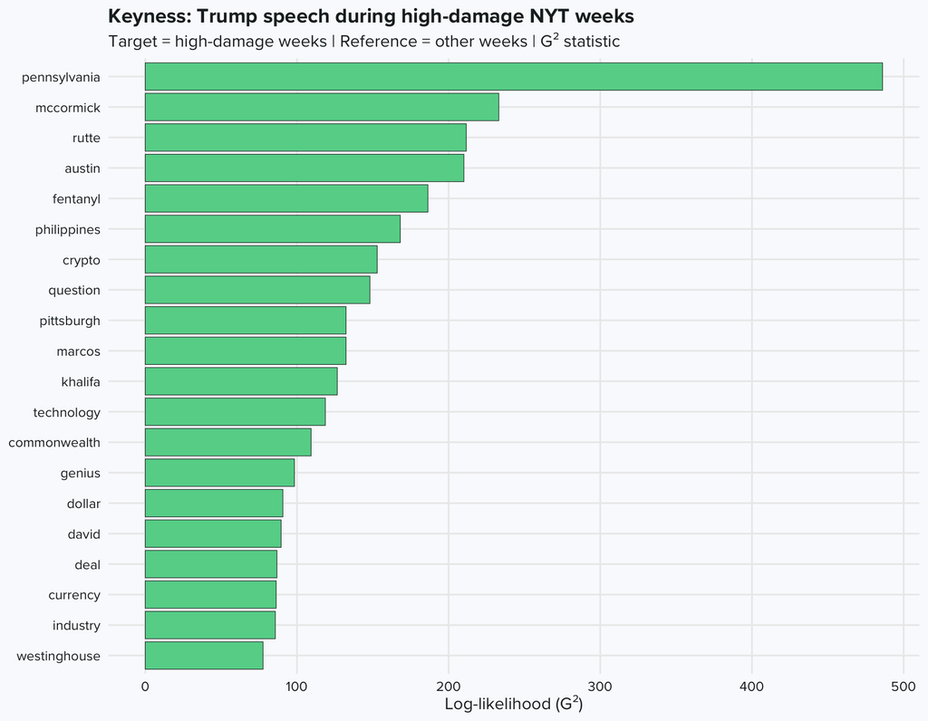

```r
# Lab 2: log-likelihood (G²) for words over-used in target vs reference corpus
corp <- corpus(speech_key, text_field = "body_trump", docid_field = "doc_id")
docvars(corp, "period") <- speech_key$period

toks <- tokens(corp) |>
  tokens_tolower() |>
  tokens_remove(all_sw) |>
  tokens_select(pattern = "^[a-z]{3,}$", valuetype = "regex", selection = "keep")

dfmat <- dfm(toks)
dfmat_g <- dfm_group(dfmat, groups = docvars(dfmat, "period"))  # collapse to 2 groups

result <- textstat_keyness(dfmat_g, target = "high_damage", measure = "lr")

key_plot_df <- as_tibble(result) |>
  filter(G2 > 0) |>
  arrange(desc(G2)) |>
  slice_head(n = 20)

ggplot(key_plot_df, aes(G2, reorder(feature, G2))) +
  geom_col(fill = col_accent, color = col_dark, linewidth = 0.2) +
  labs(
    title = "Keyness: Trump speech during high-damage NYT weeks",
    subtitle = "Target = high-damage weeks | Reference = other weeks | G² statistic",
    x = "Log-likelihood (G²)", y = NULL
  ) +
  theme_project()
```

Whatever lands at the top of this chart is what Trump over-uses when damaging NYT coverage is running hot — relative to his own speech in calmer weeks. Conflict-flavored terms showing up there would support the distraction read; environmental terms would cut against it. Worth remembering that keyness measures *unusualness*, not importance: a word can spike because of one long rally or one recurring phrase.

## LDA topic groups

```r
# Lab 4: LDA with k=5 topics, Gibbs sampling
run_lda <- function(df, text_col, min_words = 50) {
  dat <- df |> filter(!is.na(date), nzchar(.data[[text_col]]), word_count >= min_words)
  corp <- corpus(dat, text_field = text_col, docid_field = "doc_id")
  toks <- tokens(corp) |>
    tokens_tolower() |>
    tokens_remove(all_sw) |>
    tokens_select(pattern = "^[a-z]{3,}$", valuetype = "regex", selection = "keep")
  dfm_mat <- dfm_trim(dfm(toks), min_docfreq = 3)
  dtm <- quanteda::convert(dfm_mat, to = "topicmodels")
  mod <- LDA(dtm, k = 5, method = "Gibbs", control = list(iter = 500, seed = 321))
  list(model = mod, data = dat)
}

assign_group <- function(terms) {
  # Map each topic to Conflict / Damaging / Environmental / Other via keyword overlap
  terms <- tolower(terms)
  scores <- c(
    Conflict = sum(terms %in% conflict_words),
    Damaging = sum(terms %in% damage_words),
    Environmental = sum(terms %in% env_words)
  )
  if (max(scores) == 0) return("Other")
  names(which.max(scores))
}

label_topics <- function(mod) {
  tidy(mod, matrix = "beta") |>
    group_by(topic) |>
    slice_max(beta, n = 10) |>
    summarise(terms = list(term), .groups = "drop") |>
    mutate(
      topic = as.character(topic),
      top_terms = map_chr(terms, ~ paste(.x, collapse = ", ")),
      group = map_chr(terms, ~ assign_group(.x)),
      label = paste0("T", topic, ": ", group)
    )
}
```

```r
speech_lda <- run_lda(speech_df, "body_trump")
speech_labels <- label_topics(speech_lda$model)
knitr::kable(speech_labels |> select(topic, group, top_terms),
             caption = "Speech LDA topics → named groups")
```

Speech LDA topics → named groups

| topic | group | top_terms |
| --- | --- | --- |
| 1 | Other | great, good, time, unidentified, world, beautiful, lot, love, job, incredible |
| 2 | Other | question, crime, lot, great, back, safe, job, time, bad, good |
| 3 | Other | great, good, lot, thing, big, time, money, back, make, job |
| 4 | Conflict | question, lot, great, deal, good, peace, war, countries, world, things |
| 5 | Other | great, today, make, lot, care, health, secretary, americans, drugs, time |

```r
nyt_lda <- run_lda(nyt_overlap, "text", min_words = 10)
nyt_labels <- label_topics(nyt_lda$model)
knitr::kable(nyt_labels |> select(topic, group, top_terms),
             caption = "NYT LDA topics → named groups")
```

NYT LDA topics → named groups

| topic | group | top_terms |
| --- | --- | --- |
| 1 | Damaging | democrats, political, epstein, republicans, department, charlie, justice, public, kirk, republican |
| 2 | Conflict | tariffs, trade, deal, war, latest, end, week, tariff, russian, talks |
| 3 | Other | state, city, national, leaders, democratic, mayor, leader, mamdani, world, plan |
| 4 | Other | federal, administration, officials, court, government, judge, fed, law, cuts, move |
| 5 | Environmental | immigration, back, climate, health, top, work, police, efforts, workers, change, control, readers, force |

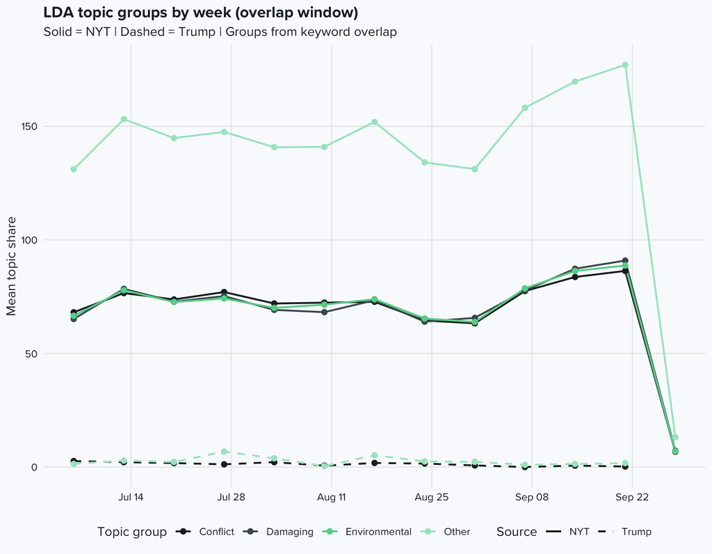

```r
# Sum topic proportions (gamma) by week and named group, overlap docs only
topic_over_time <- function(lda_obj, labels, source_name, time_col = "week") {
  dat <- lda_obj$data |>
    filter(date >= overlap_start, date <= overlap_end)

  theta <- as.data.frame(posterior(lda_obj$model)$topics)  # doc-topic proportions
  theta$doc_id <- lda_obj$data$doc_id[as.integer(rownames(theta))]

  theta |>
    filter(doc_id %in% dat$doc_id) |>
    pivot_longer(-doc_id, names_to = "topic", values_to = "gamma") |>
    mutate(topic = sub("^X", "", topic)) |>
    left_join(dat |> select(doc_id, period = all_of(time_col)), by = "doc_id") |>
    left_join(labels |> select(topic, group, label), by = "topic") |>
    group_by(period, group, source = source_name) |>
    summarise(mean_gamma = sum(gamma), .groups = "drop")
}

lda_combined <- bind_rows(
  topic_over_time(speech_lda, speech_labels, "Trump"),
  topic_over_time(nyt_lda, nyt_labels, "NYT")
)

lda_combined_norm <- lda_combined |>
  group_by(source, group) |>
  mutate(
    z_gamma = (mean_gamma - mean(mean_gamma, na.rm = TRUE)) /
      sd(mean_gamma, na.rm = TRUE)  # z-score within each source + topic group
  ) |>
  ungroup()

lda_combined |>
  ggplot(aes(period, mean_gamma, color = group, linetype = source)) +
  geom_line(linewidth = 0.8) +
  geom_point(size = 2) +
  scale_color_manual(
    values = c(
      "Conflict" = col_dark,
      "Damaging" = "#4a5a5e",
      "Environmental" = col_accent,
      "Other" = "#a8e6c8"
    )
  ) +
  scale_linetype_manual(values = c("NYT" = "solid", "Trump" = "dashed")) +
  scale_x_date(date_labels = "%b %d", date_breaks = "2 weeks") +
  labs(
    title = "LDA topic groups by week (overlap window)",
    subtitle = "Solid = NYT | Dashed = Trump | Groups from keyword overlap",
    x = NULL, y = "Mean topic share", color = "Topic group", linetype = "Source"
  ) +
  theme_project()
```

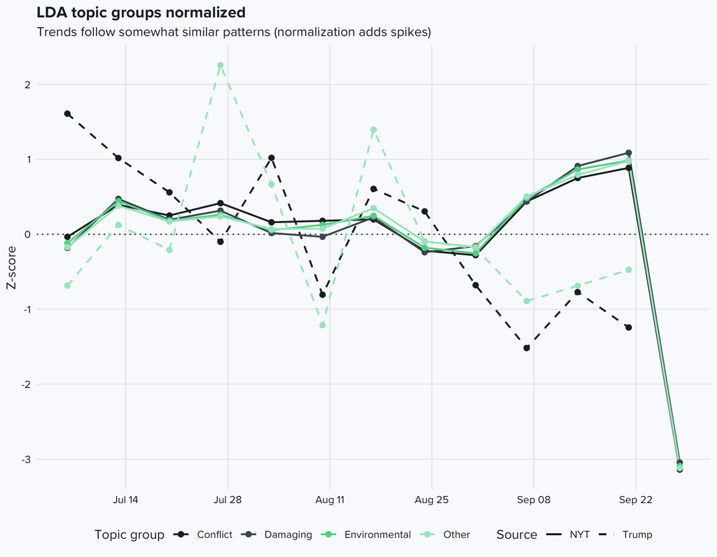

```r
lda_combined_norm |>
  ggplot(aes(period, z_gamma, color = group, linetype = source)) +
  geom_hline(yintercept = 0, linetype = "dotted", color = col_dark) +
  geom_line(linewidth = 0.8) +
  geom_point(size = 2) +
  scale_color_manual(
    values = c(
      "Conflict" = col_dark,
      "Damaging" = "#4a5a5e",
      "Environmental" = col_accent,
      "Other" = "#a8e6c8"
    )
  ) +
  scale_linetype_manual(values = c("NYT" = "solid", "Trump" = "dashed")) +
  scale_x_date(date_labels = "%b %d", date_breaks = "2 weeks") +
  labs(
    title = "LDA topic groups normalized",
    subtitle = "Trends follow somewhat similar patterns (normalization adds spikes)",
    x = NULL, y = "Z-score", color = "Topic group", linetype = "Source"
  ) +
  theme_project()
```

## Wrapping up

The distraction hypothesis, scandal up, climate talk down, gets partial support at best. Some high-damage weeks show conflict rhetoric rising without much drop in environmental keywords. That could mean the lists miss how he actually talks about climate, or that he doesn’t drop environment talk as cleanly as my theory suggested.

Of course this analysis was meant to practice and explore course concepts. The data and methods have limitations:

- NYT stops at Sep 28, 2025 (rate limit); speeches continue for months after
- Snippets aren’t full articles; Bing and LDA on NYT side are noisy
- Keyword lists are blunt; `ice` omitted on purpose
- Bing ignores negation (“not good” still counts positive)
- Same-week correlation isn’t strategy or causation